# Examining the Nexus of Race, Party Identity Importance & PartyID in Shaping Political Ideology

Oladipo Vanessa Dolapo

2023-10-28

[figure not shown]

A symbolic representation of ideology and race conflict. Source: google

## Motivation

In study one I examined the relationship between Race, Ideology & PartyID using the CCES dataset and I discovered that the relationship between party id and ideology depends on the racial identity of the respondent. To strengthen my argument, I am utilizing the 2020 ANES dataset and introducing a new variable called “Party Identity Importance” to see if it can enhance the performance of my analysis. In a nutshell, this study aims to explore the relationships between Race, Party Identity Importance, Party ID and how these factors collectively shape an individual’s political ideology. Understanding these relationships is not only essential for academics and researchers but also for policymakers, political strategists, and anyone interested in the intricacies of contemporary politics and its impact on society.

## Variable selection

The Dependent Variable is: **Party ideology**(V201200)

The Independent Variables are:**PartyID**(V201018),**Race**(V201549x),**Party Identity Importance**(V201232)

## Research Question

Is there a relationship between race, party identity importance and party ID on political ideology?

## Hypothises

$H_1$ race, party identity importance and party ID will affect ideology.

$H_2$ whether the respondent is black or not will have an effect on their ideology.

$H_3$ as party identity importance increases, ideology will change.

### Creating a new data frame

```r
anes_clean <- data.frame(matrix(NA, nrow = 8280, ncol = 0))
```

### Step one

Filing the new data frame with information that characterizes racial demographics. I am classifying the value 2 as “Black” while assigning 1, 3, 4, 5, 6, as “Non-black” and creating a table for easy readability.

```r
anes_clean$race <- NA

anes_clean$race[anes_full$V201549x == 2] <- "Black"
anes_clean$race[anes_full$V201549x == 1 | anes_full$V201549x == 3 | anes_full$V201549x == 4 | anes_full$V201549x == 5 | anes_full$V201549x == 6]  <- "Non_Black"


table_result <- table(anes_clean$race)

pander(table_result)
```

| Black | Non_Black |
| --- | --- |
| 726 | 7452 |

### Step two

Filing the new data frame with information that characterizes “Ideology”, going from extremely liberal(-2) to extremely conservative (2) and also creating a table for easy readability.

```r
anes_clean$ideology <- NA
anes_clean$ideology[anes_full$V201200 == 1] <- -2
anes_clean$ideology[anes_full$V201200 == 2] <- -1
anes_clean$ideology[anes_full$V201200 == 3] <- 0
anes_clean$ideology[anes_full$V201200 == 4] <- 0
anes_clean$ideology[anes_full$V201200 == 5] <- 0
anes_clean$ideology[anes_full$V201200 == 6] <- 1
anes_clean$ideology[anes_full$V201200 == 7] <- 2


table_result <-table(anes_clean$ideology)

pander(table_result)
```

| -2 | -1 | 0 | 1 | 2 |
| --- | --- | --- | --- | --- |
| 369 | 1210 | 3557 | 1492 | 428 |

### Step three

Filing the new data frame with information that characterizes “Political Party Identity”, where 1 means democratic party, 2 means republican party and 4,5,-1,-8 means neither. I am also creating a table for easy readability of the results.

```r
anes_clean$party <- NA
anes_clean$party [anes_full$V201018 == 1] <- "Democratic party"
anes_clean$party [anes_full$V201018 == 2] <- "Republican party"
anes_clean$party [anes_full$V201018 == 4 | anes_full$V201018 == 5 | anes_full$V201018 == -1 | anes_full$V201018 == -8] <- "Neither"


table_result <- table(anes_clean$party)

pander(table_result)
```

| Democratic party | Neither | Republican party |
| --- | --- | --- |
| 1861 | 5074 | 1336 |

### Step four:

Filing the new data frame with information that characterizes “Party Identity Importance”, going from Extremely important (5) to Not at all important (1). I also created a table for easy readability

```r
anes_clean$party_i.i <- NA
anes_clean$party_i.i [anes_full$V201232 == -9 | anes_full$V201232 == -8 | anes_full$V201232 == -1] <- NA
anes_clean$party_i.i [anes_full$V201232 == 1] <- 5
anes_clean$party_i.i [anes_full$V201232 == 2] <- 4
anes_clean$party_i.i [anes_full$V201232 == 3] <- 3
anes_clean$party_i.i [anes_full$V201232 == 4] <- 2
anes_clean$party_i.i [anes_full$V201232 == 5] <- 1

table_result <- table(anes_clean$party_i.i)

pander(table_result)
```

| 1 | 2 | 3 | 4 | 5 |
| --- | --- | --- | --- | --- |
| 1813 | 1248 | 2089 | 1751 | 1044 |

### Step Five:

Creating a linear model.

```r
mod_1 <- lm(ideology ~ party * race + party_i.i, anes_clean)
```

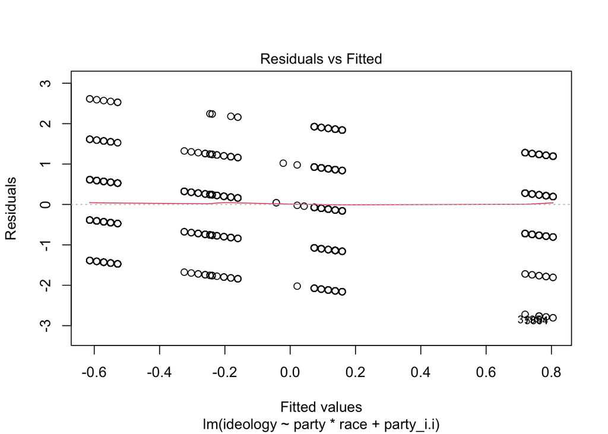

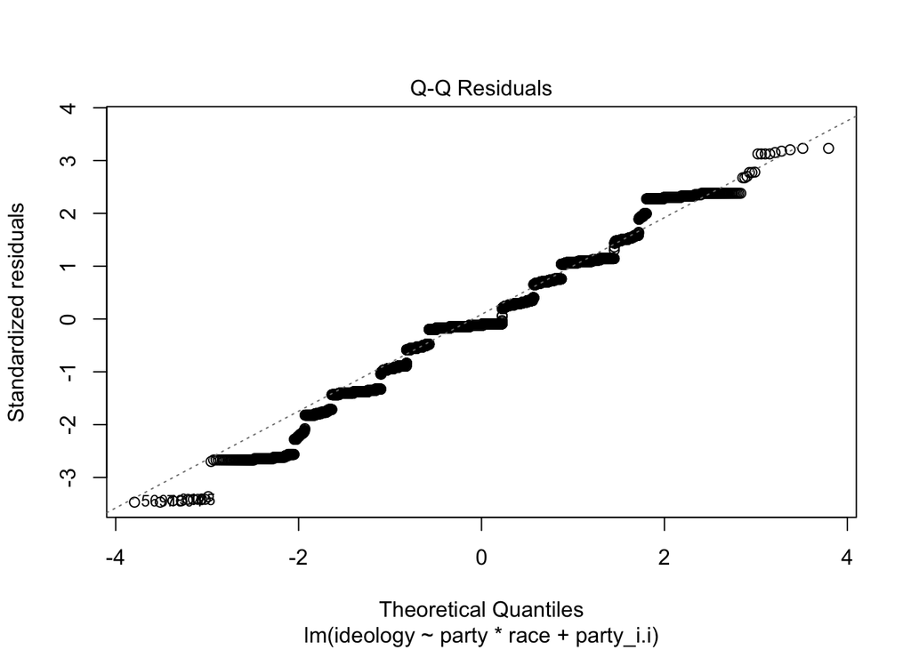

```r
plot(mod_1, which = 1:2)
```

### Analysis 1

Residuals vs fitted plot will help me to check two assumptions which are the assumptions of linearity and equal variance.

the assumption of linearity is met. the assumption of have equal variance (Homoscedasticity) is not met.

## Plotting the graph in other to properly analyze the different variables.

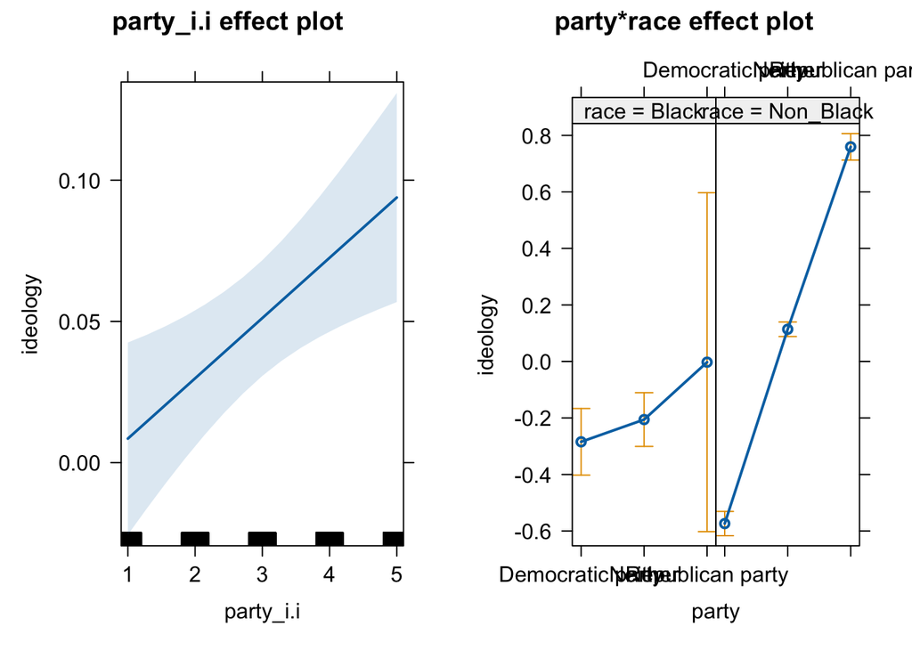

```r
plot(allEffects(mod_1))
```

### Analysis 2

```r
pander(summary(mod_1))
```

|  | Estimate | Std. Error | t value | Pr(>\|t\|) |
| --- | --- | --- | --- | --- |
| **(Intercept)** | -0.3458 | 0.06487 | -5.33 | 1.011e-07 |
| **partyNeither** | 0.07867 | 0.07713 | 1.02 | 0.3078 |
| **partyRepublican party** | 0.2818 | 0.3117 | 0.9039 | 0.3661 |
| **raceNon_Black** | -0.2894 | 0.06393 | -4.527 | 6.074e-06 |
| **party_i.i** | 0.02134 | 0.00741 | 2.879 | 0.003996 |
| **partyNeither:raceNon_Black** | 0.609 | 0.08124 | 7.496 | 7.396e-14 |
| **partyRepublican party:raceNon_Black** | 1.051 | 0.3134 | 3.355 | 0.000798 |

Fitting linear model: ideology ~ party * race + party_i.i

| Observations | Residual Std. Error | $R^2$ | Adjusted $R^2$ |
| --- | --- | --- | --- |
| 6761 | 0.8093 | 0.2074 | 0.2067 |

### Analysis 3

1. the y intercept(-0.34577) represents the estimated ideology for Black Democrats with party importance equal to this cannot be interpreted meaningfully because there is no party identity importance 0 but if there was it would be moderate and leaning towards liberal.
2. The coefficient for ‘partyNeither’ (0.07867) represents the estimated difference in ideology between individuals who do not belong to any political party and Democrats. On average, they tend to be 0.07 units more conservative than Democrats. However, the p-value (0.3078) suggests that this difference is not statistically significant. In other words, the p-value of 0.3078 indicates a 30% chance of observing such a difference between people who do not belong to a political party and Democrats, assuming the null hypothesis is true. Compared to Black Democrats, this group exhibits a slightly more conservative ideology.
3. People in Republican party are 0.28176 more conservative than people who are black democrats with zero party importance.The p-value (0.3661) is high, suggesting that this difference is not statistically significant.
4. raceNon_Black (-0.2894) represents the estimated difference in ideology between non-Black individuals and Black Democrats. The p-value (6.074e-06) is very low, indicating that non-Black individuals have significantly different ideologies from Black Democrats.
5. party_i.i (0.02134) represents the change in ideology for a one-unit increase in party importance. The positive coefficient suggests that as party importance increases, ideology becomes more conservative. The p-value (0.003996) is less than 0.05, indicating that this effect is statistically significant.